# дз4

2023-05-23

# Домашнее задание №4. Софья Скобелева

Посмотрим на наши данные.

```r
data4 <- read_dta('hwdata.dta')
head(data4)
```

```
## # A tibble: 6 × 13
##   masterid   afreq province     uezd  serfperc1 distance_moscow goodsoil lnurban
##      <dbl>   <dbl> <chr>        <chr>     <dbl>           <dbl>    <dbl>   <dbl>
## 1        1  0.0769 Arkhangel'sk Arkh…   3.50e-4           1.07     0.254    9.91
## 2        2  0      Arkhangel'sk Kems…   0                 1.28     0.234    7.70
## 3        3 NA      Arkhangel'sk Kol'…  NA                NA       NA       NA
## 4        4  0      Arkhangel'sk Meze…   0                 1.32     0.182    7.47
## 5        5  0      Arkhangel'sk Onez…   3.22e-5           0.886    0.206    7.51
## 6        6  0      Arkhangel'sk Pech…   0                 1.70     0.148   NA
## # ℹ 5 more variables: lnpopn <dbl>, province_capital <dbl>,
## #   ch_schools_pc <dbl>, nozemstvo <dbl>, redist <dbl>
```

# Задание 1

1.Удалим из датафрейма data4 все строки, содержащие пропущенные данные и **перекодируем переменную nozemstvo** так, чтобы единицей обозначались уезды тех губерний, в которых в результате реформы 1864 г. земства были созданы, нулем – уезды тех губерний, в которых земства не были созданы. В результате получим новую переменную **zemstvo**.

```r
data4 <- na.omit(data4)
data4$zemstvo <- dplyr::recode(data4$nozemstvo, "1" = "0", "0" = "1")
```

**2. Визуализируем взаимосвязь** изменения в количестве сельских школ на душу населения (ch_schools_pc – по оси ординат) и доли лет, в которые были зафиксированы крестьянские выступления (afreq – по оси aбсцисс), в группах, сформированныx по признаку «наличие земства» и «отсутствие земства».

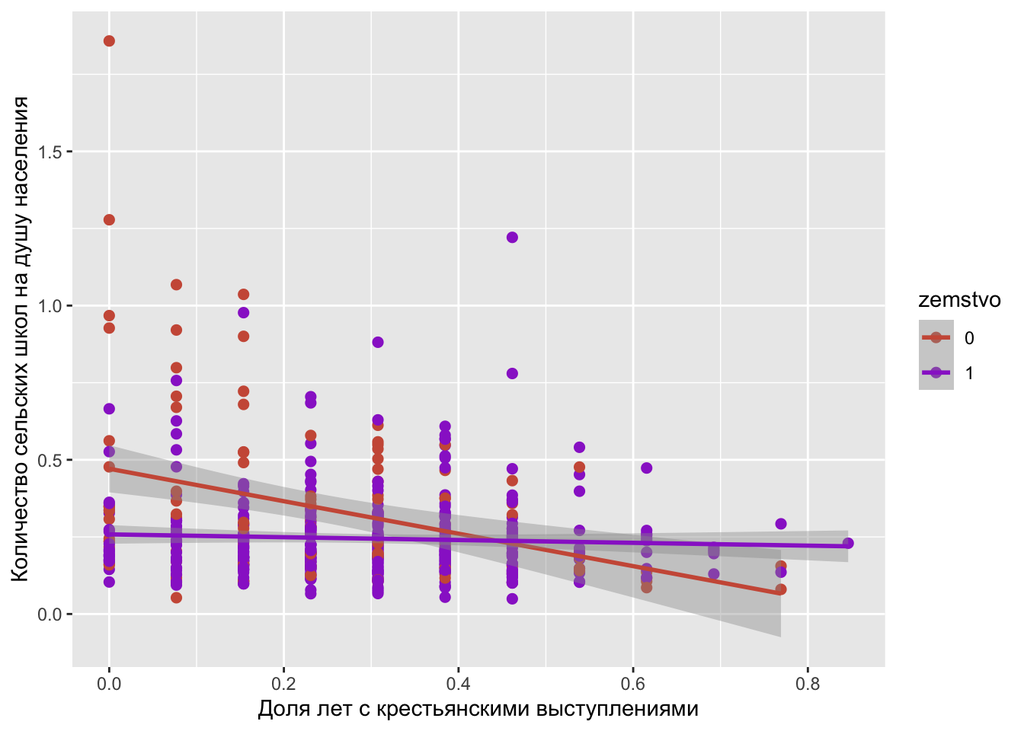

```r
ggplot(data = data4, aes(x = afreq, y = ch_schools_pc, color = zemstvo)) +
  geom_point(size=2) + labs(x = "Доля лет с крестьянскими выступлениями",
                            y = "Количество сельских школ на душу населения") +
  geom_smooth(method=lm)+ scale_colour_manual(values = c("coral3", "darkorchid3"))
```

**По графику можно сделать следующие выводы**.  
**В губерниях, в которых в результате реформы 1864 года земства были созданы** скорее всего **незначимая взаимосвязь** между количеством сельских школ и долей лет с крестьянскими выступлениями (так как эффект слабо выражен).  
**В губерниях, в которых в результате реформы 1864 года земства не были созданы** **выраженная отрицательная линейная взаимосвязь** между количеством сельских школ и долей лет с крестьянскими выступлениями.  
Следовательно, можно предположить наличие модератора zemstvo, при наличии или отсутсвии которого взаимосвязь меняет свою значимость.  
**3. Приведем описательные статистики для оценивания регрессионной модели.**

Предварительные описательные статистики особенно важны в контексте регрессионного анализа, так как позволяют получить общее представление о данных (распределение переменных, наличие/отсутсвие выбросов, корреляции между переменными и др.). Эта информация может быть полезна при выборе модели регресии и при интерпретации результатов. Приведем описательные статистики для переменных ch_schools_pc и afreq.

```r
summary(data4$ch_schools_pc)
```

```
##    Min. 1st Qu.  Median    Mean 3rd Qu.    Max.
## 0.04928 0.16023 0.21763 0.26956 0.31324 1.85811
```

```r
summary(data4$afreq)
```

```
##    Min. 1st Qu.  Median    Mean 3rd Qu.    Max.
##  0.0000  0.1538  0.3077  0.2825  0.3846  0.8462
```

Для более удобной интерпретации центрируем предиктор afreq.

```r
data4$afreq <- data4$afreq - mean(data4$afreq)
```

Построим регрессионную модель с переменной взаимодействия.

```r
m3 <- lm(ch_schools_pc ~ afreq*zemstvo, data = data4)
summary(m3)
```

```
##
## Call:
## lm(formula = ch_schools_pc ~ afreq * zemstvo, data = data4)
##
## Residuals:
##      Min       1Q   Median       3Q      Max
## -0.37762 -0.09683 -0.03991  0.04626  1.38720
##
## Coefficients:
##                Estimate Std. Error t value Pr(>|t|)
## (Intercept)     0.32226    0.01627  19.802  < 2e-16 ***
## afreq          -0.52624    0.08923  -5.897 6.94e-09 ***
## zemstvo1       -0.07702    0.01872  -4.115 4.55e-05 ***
## afreq:zemstvo1  0.48064    0.10583   4.542 7.06e-06 ***
## ---
## Signif. codes:  0 '***' 0.001 '**' 0.01 '*' 0.05 '.' 0.1 ' ' 1
##
## Residual standard error: 0.176 on 484 degrees of freedom
## Multiple R-squared:  0.1176, Adjusted R-squared:  0.1121
## F-statistic:  21.5 on 3 and 484 DF,  p-value: 4.378e-13
```

**4. Добавим в модель контрольные переменные.**

```r
m4 <- lm(ch_schools_pc ~ afreq*zemstvo + distance_moscow + goodsoil + lnurban + lnpopn + province_capital, data = data4)
summary(m4)
```

```
##
## Call:
## lm(formula = ch_schools_pc ~ afreq * zemstvo + distance_moscow +
##     goodsoil + lnurban + lnpopn + province_capital, data = data4)
##
## Residuals:
##      Min       1Q   Median       3Q      Max
## -0.39528 -0.09236 -0.03538  0.04310  1.37753
##
## Coefficients:
##                   Estimate Std. Error t value Pr(>|t|)
## (Intercept)       0.617552   0.218103   2.831  0.00483 **
## afreq            -0.506404   0.091734  -5.520 5.55e-08 ***
## zemstvo1         -0.066728   0.021694  -3.076  0.00222 **
## distance_moscow  -0.002617   0.031372  -0.083  0.93355
## goodsoil         -0.021884   0.023735  -0.922  0.35700
## lnurban           0.011595   0.007164   1.618  0.10622
## lnpopn           -0.034114   0.019601  -1.740  0.08242 .
## province_capital  0.039824   0.029635   1.344  0.17964
## afreq:zemstvo1    0.466060   0.106492   4.376 1.48e-05 ***
## ---
## Signif. codes:  0 '***' 0.001 '**' 0.01 '*' 0.05 '.' 0.1 ' ' 1
##
## Residual standard error: 0.1749 on 479 degrees of freedom
## Multiple R-squared:  0.1377, Adjusted R-squared:  0.1233
## F-statistic: 9.561 on 8 and 479 DF,  p-value: 2.584e-12
```

Посмотрим, изменились ли значимым образом результаты. Коэффициент при предикторе zemstvo стал менее значимыми (1% по сравнению с предыдущей значимостью 0,1%) Коэффициенты при предикторе afreq и при переменной взаимодействия так же, как и в предыдущей модели, значимы на уровне 0,1%.  
$R^2$ увеличился и равен 0.1377, то есть объяснительная сила модели стала выше, так как мы добавили больше предикторов.  
В целом можно сказать, что результаты изменились незначимо.

5. Следовательно, результаты соотносятся с предположением авторов о характере взаимного влияния Земской реформы и крестьянских выступлении,так как переменная взаимодействия оказалась значима на уровне 0,1%.

# Задание 2

Оценим регрессионную модель, в которой тестируется взаимный эффект показателя плодородности почвы (goodsoil) и логарифма городского населения уезда на 1863 г. (lnurban) на изменение в количестве сельских школ на душу населения (ch_schools_pc). Остальные показатели (afreq, nozemstvo, distance_moscow, lnpopn, province_capital) используем как контрольные.

```r
m6 <- lm(ch_schools_pc ~ goodsoil*lnurban + afreq + zemstvo + distance_moscow + lnpopn + province_capital, data=data4)
summary(m6)
```

```
##
## Call:
## lm(formula = ch_schools_pc ~ goodsoil * lnurban + afreq + zemstvo +
##     distance_moscow + lnpopn + province_capital, data = data4)
##
## Residuals:
##      Min       1Q   Median       3Q      Max
## -0.34034 -0.09606 -0.03592  0.04657  1.45646
##
## Coefficients:
##                   Estimate Std. Error t value Pr(>|t|)
## (Intercept)       0.728589   0.228446   3.189 0.001520 **
## goodsoil         -0.073863   0.171667  -0.430 0.667193
## lnurban           0.008807   0.014943   0.589 0.555875
## afreq            -0.181306   0.054559  -3.323 0.000958 ***
## zemstvo1         -0.082836   0.022055  -3.756 0.000194 ***
## distance_moscow  -0.014170   0.032294  -0.439 0.661019
## lnpopn           -0.040039   0.020583  -1.945 0.052324 .
## province_capital  0.041974   0.031375   1.338 0.181581
## goodsoil:lnurban  0.007402   0.019521   0.379 0.704701
## ---
## Signif. codes:  0 '***' 0.001 '**' 0.01 '*' 0.05 '.' 0.1 ' ' 1
##
## Residual standard error: 0.1783 on 479 degrees of freedom
## Multiple R-squared:  0.1035, Adjusted R-squared:  0.08851
## F-statistic: 6.911 on 8 and 479 DF,  p-value: 1.26e-08
```

Значимыми являются коэффициенты при предикторах afreq (на уровне значимости 0,1%), nozemstvo (на уровне значимости 0,1%) и lnpopn (на уровне значимости 10%).  
$R^2$ равен 0.1035, то есть полученная модель объясняет 10,35% вариации зависимой переменной ch_schools_pc.

Посмотрим, как изменяется предельный эффект плодородности почвы и его значимость в зависимости от «условия» (показателя городского населения).  
**Спецификация модели:** ch_schools_pc^ = b^0 + b^1⋅goodsoil + b^2⋅lnurban + b^3⋅afreq + b^4⋅zemstvo + b^5⋅distance_moscow + b^6⋅lnpopn + b^7⋅province_capital + b^8⋅goodsoil⋅lnurban  
ME = b^1 + b^8 * lnurban = -0.0738631 + 0.0074024 * lnurban

```r
me <- margins(m6, at = list(lnurban = seq(min(data4$lnurban), max(data4$lnurban), by = 1)))
```

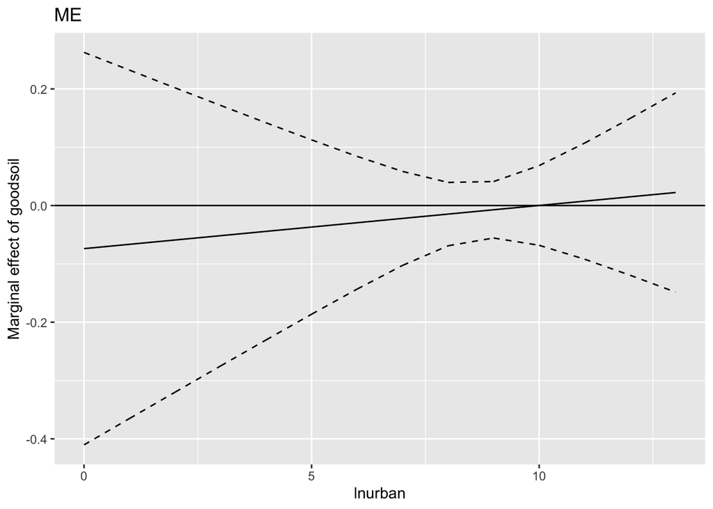

```r
ggplot(me, aes(lnurban, dydx_goodsoil)) + geom_line() +
  geom_line(aes(y = dydx_goodsoil+1.96*sqrt(Var_dydx_goodsoil)), linetype = 2) +
  geom_line(aes(y = dydx_goodsoil-1.96*sqrt(Var_dydx_goodsoil)), linetype = 2) +
  geom_hline(yintercept = 0) + ggtitle("ME") + xlab("lnurban") + ylab("Marginal effect of goodsoil")
```

# Задание 3

Авторы данной статьи среди ошибок, допускаемых исследователями при оценивании линейной регрессионной модели, выделяют неверную функциональную форму модели (предположение линейной связи в том случае, когда связь нелинейна) и недостаточное количество данных. Как видно на графиках связь в нашей модели линейная, поэтому проблемы с функциональной формой модели возникнуть не должно. Но проблема с нехваткой данных может быть для нас актуальна, так как по графику предельного эффекта можно сделать вывод, что данные за многие годы могут отсутсвовать, поэтому экстраполяция результатов данного исследования будет некорректным решением.